# Assigntment 1 - Densitiy Estimation Advanced Multivariate Analysis (AMA) Facultat d’Informàtica de Barcelona (FIB) Universitat Politècnica de Catalunya (UPC) - BarcelonaTech

Bandwidht choice by leave-one-out maximum likelihood

Joan Oliveras Torra, Odysseas Kyparissis, Louis Tichelman

2023-10-26

```r
knitr::opts_chunk$set(echo = TRUE)

# Clear plots from the R plots view:
if(!is.null(dev.list())) dev.off()
```

```r
# Clean workspace - No variables at the current workspace
rm(list=ls())

# Installing libraries
install.packages("rstudioapi", repos = "https://cran.rstudio.com/")
```

```r
install.packages("ggplot2", repos = "https://cran.rstudio.com/")
# Setting working directory
# script_directory <- dirname(rstudioapi::getActiveDocumentContext()$path)
# setwd(script_directory)

library(ggplot2)
```

# Histogram

## Exercise 1

A similar relationship to that of the `leave-one-out kernel density estimator,` $\hat{f}_{h, (-i)}(x_i)$, and the `kernel density estimator using all the observations`, $\hat{f}_{h}(x_i)$, when *both are evaluated at one of the observed data*, is holding between the `histogram estimator of the density function`,$\hat{f}_{hist}(x_i)$, and its `leave-one-out` version, $\hat{f}_{hist, (-i)}(x_i)$, when again *both are evaluated at a single observed point*. The relationship is presented here:

$$\begin{align*}
\hat{f}_{hist, (-i)}(x_i)&=\frac{1}{n-1}\sum_{k\neq
i}\frac{1}{b}I_{B_{j(x_i)}}(x_k) \\ &=
\frac{1}{(n-1)b}\Big(\big(\sum_{k=1 }^n I_{B_{j(x_i)}}(x_k)\big)
-1\Big)=\frac{n}{n-1}\Big(\hat{f}_{hist}(x_i)-\frac{1}{nb}\Big).
\end{align*}$$

## Exercise 2

After reading the *`CDrate dataset`*, we call `x` the first column, and the variables *`A`*, *`Z`* and *`nbr`* are defined as mentioned in the statement. The histogram of variable *`x`* is presented in the following figure:

```r
cdrate.df <-read.table("cdrate.dat")
x <- cdrate.df[,1]
A<- min(x)-.05*diff(range(x))
Z<- max(x)+.05*diff(range(x))
nbr<-7
```

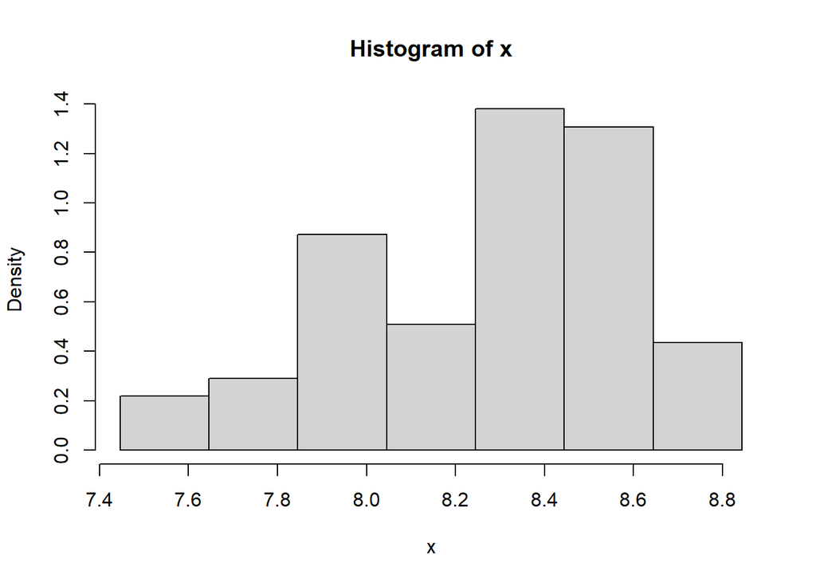

```r
hx<- hist(x,breaks=seq(A,Z,length=nbr+1),freq=F)
```

With the usage of the function *`stepfun`* the above histogram is being converted into a function *`hx_f`* that can be evaluated at any point of $\mathbb{R}$, or at a vector of real numbers. By using this function, the histogram generated above is being evaluated at the vector of observed data *`x`*. Moreover, the histogram accompanied with all the points ( $x_i, \hat{f}_{hist}(x_i)$) for $i=1,...,n$ are included in the following figure.

```r
hx_f<-stepfun(hx$breaks,c(0,hx$density,0))
```

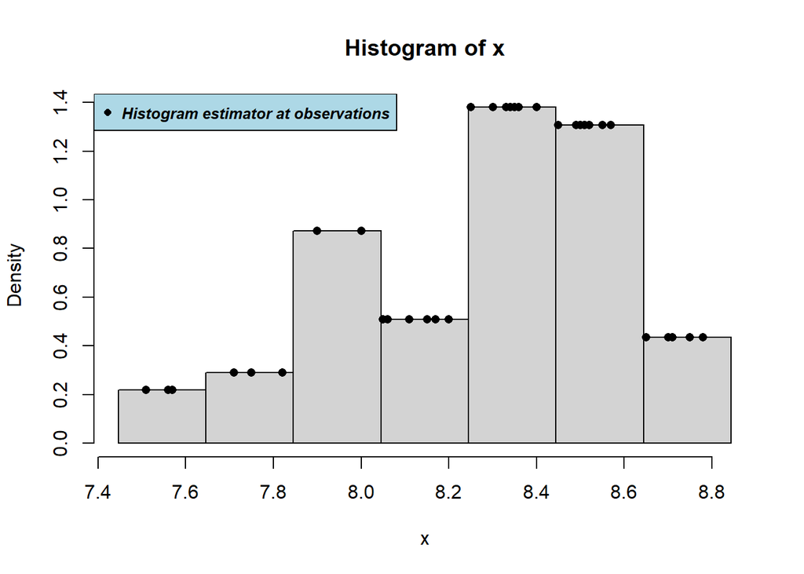

```r
hist(x,breaks=seq(A,Z,length=nbr+1),freq=F)
points(x,hx_f(x), pch = 16)
legend(x="topleft", legend=c("Histogram estimator at observations"),
       col=c("black"), cex=0.8,
       text.font=4, bg='lightblue', pch = c(16, 16))
```

## Exercise 3

By using the formula of *`exercise 1`* and the histogram estimator of *`exercise 2`*, $\hat{f}_{hist}(x_i)$, the values of $\hat{f}_{hist, (-i)}(x_i)$ are calculated for $i=1,...,n$. Moreover the new points are added to the previous plot. We name the function of $\hat{f}_{hist, (-i)}(x_i)$ (*`hx_f2`*) in the code.

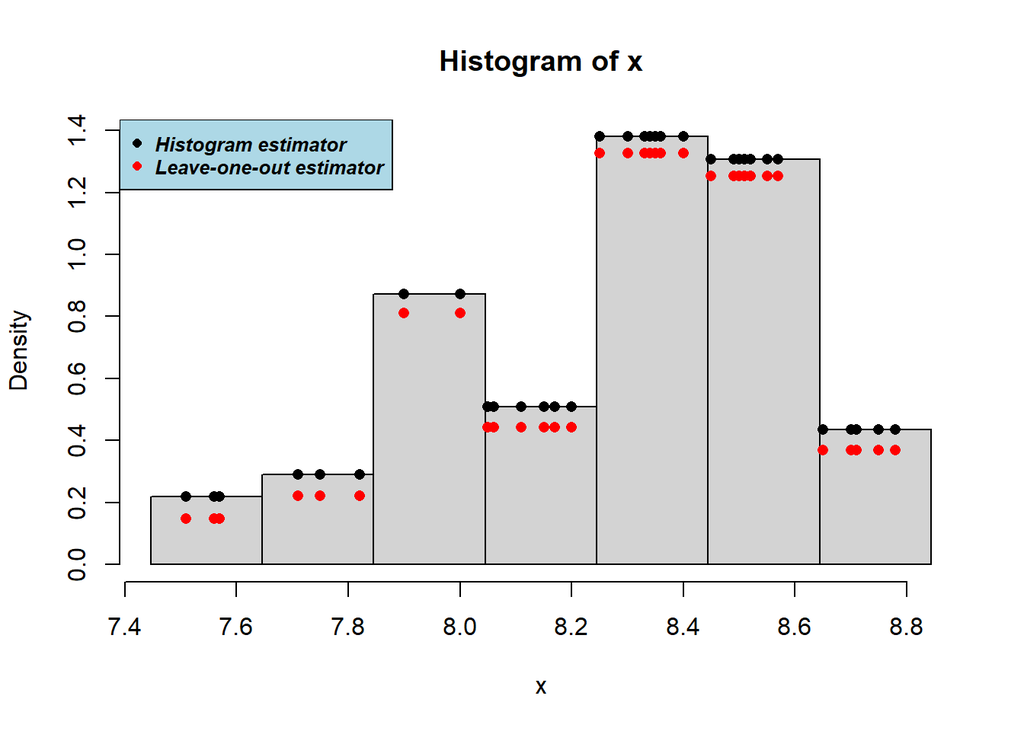

```r
b <- hx$breaks[2]-hx$breaks[1]
n <- length(x)

hx_f2 <- (n/(n-1))*(hx_f(x)-1/(n*b))

hist(x,breaks=seq(A,Z,length=nbr+1),freq=F)
points(x,hx_f(x), pch = 16)
points(x,hx_f2,col='red', pch = 16)
legend(x="topleft", legend=c("Histogram estimator", "Leave-one-out estimator"),
       col=c("black", "red"), cex=0.8,
       text.font=4, bg='lightblue', pch = c(16, 16))
```

## Exercise 4

In this part of the report, the *`leave-one-out log-likelihood function`* corresponding to the previous histogram is being calculated with the following formula, and the *`number of breaks`* that has been used is equal to 7.

```r
L7=prod(hx_f2)
looCV_log_lik=sum(log(hx_f2))
```

The result of the function is presented here:

```r
print("The leave-one-out log-likelihood for nbr=7 is:")
```

```
## [1] "The leave-one-out log-likelihood for nbr=7 is:"
```

```r
print(looCV_log_lik)
```

```
## [1] -16.58432
```

## Exercise 5

In this exercise we are repeating the same process as before, but this time we are iterating through different values for the *`number of intervals of the histogram`* in the range: $[1,...,15]$. For each of them the *`leave-one-out log-likelihood function`* (*`looCV_log_lik`*) is computed, once the respected histogram has been firstly generated. Additionally, the values of *`looCV_log_lik`* are plotted against the values of *`number of intervals`* and the optimal value of the intervals is selected. For selecting the optimal value, we compare the results of the *`looCV_log_lik`* function, and the one with the maximum values is considered to be the best result. Finally, the histogram of *`x`* is plotted by using the optimal value of *`number of intervals`*. The mentioned plots are presented in the following figures.

```r
likelihood_k <- c()

for (k in 1:15){
  hx <- hist(x,breaks=seq(A,Z,length=k+1), plot = FALSE)
  hx_f <- stepfun(hx$breaks,c(0,hx$density,0))
  #points(x,hx_f(x))
  b=hx$breaks[2]-hx$breaks[1]
  n=length(x)

  hx_f2 <- (n/(n-1))*(hx_f(x)-1/(n*b))
  hx_f2[hx_f2<0] <- 0
  #points(x,f0,col='red')
  looCV_log_lik=sum(log(hx_f2))
  likelihood_k <- append(likelihood_k,looCV_log_lik)
}

best_k <- which.max(likelihood_k)
```

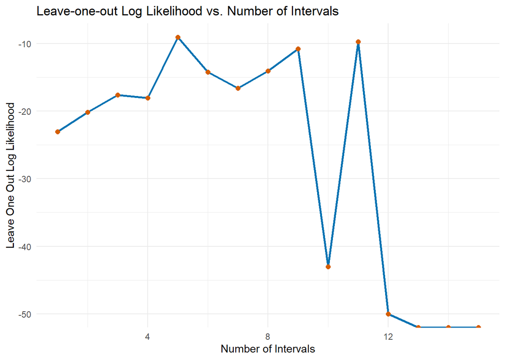

[output not shown]

```r
log_likelihood_nbr_df <- data.frame("nbr" = seq(1:15), "looLogLikelihood" = likelihood_k)
# Create a line plot for log likelihood and nbr
suppressWarnings({
  ggplot(log_likelihood_nbr_df, aes(x = nbr, y = looLogLikelihood)) +
    geom_line(color = "#0072B2", size = 1) +
    geom_point(color = "#D55E00", size = 2) +
    labs(
      title = "Leave-one-out Log Likelihood vs. Number of Intervals",
      x = "Number of Intervals",
      y = "Leave One Out Log Likelihood"
    ) +
    theme_minimal()
})
```

Below the histogram for *`number of intervals`* being equal to *5* is presented:

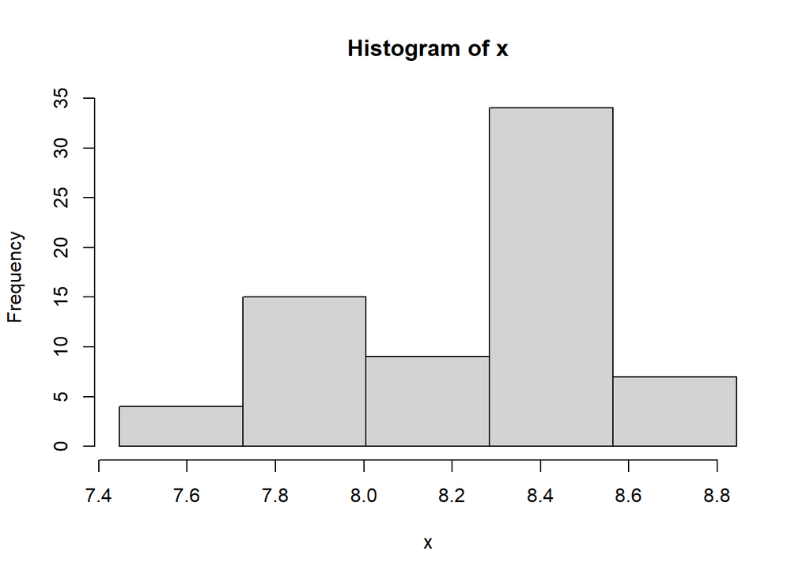

```r
hist(x,breaks=seq(A,Z,length=best_k+1), plot = TRUE)
```

## Exercise 6

In this exercise we let $b$ to be the *`common width of the bins of a histogram`*. By considering the set mentioned in the assignment’s statement, as the possible values of $b$, the `leave-one-out log-likelihood function` is calculated for each one of them. Ultimately the selection of the best value for $b$ that maximizes the `leave-one-out log-likelihood function` is taking place and the corresponding histogram is being plotted.

```r
likelihood_b <- c()

for (b in seq((Z-A)/15,(Z-A)/1,length=30)){
  hx <-  hist(x,breaks=seq(A,Z+b,by=b), plot=F)
  hx_f <- stepfun(hx$breaks,c(0,hx$density,0))
  #points(x,hx_f(x))
  #b=hx$breaks[2]-hx$breaks[1]
  n=length(x)

  hx_f2 <- (n/(n-1))*(hx_f(x)-1/(n*b))
  hx_f2[hx_f2<0] <- 0
  #points(x,f0,col='red')
  looCV_log_lik=sum(log(hx_f2))
  likelihood_b <- append(likelihood_b,looCV_log_lik)
}

best_b <- seq((Z-A)/15,(Z-A)/1,length=30)[which.max(likelihood_b)]
```

```r
print("Bin width (b) with highest leave one out log likelihood:")
```

```
## [1] "Bin width (b) with highest leave one out log likelihood:"
```

```r
print(best_b)
```

```
## [1] 0.272977
```

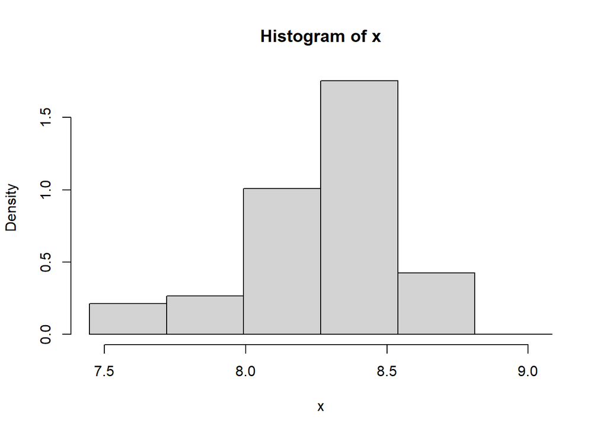

```r
hx <-  hist(x,breaks=seq(A,Z+best_b,by=best_b), plot=F)
plot(hx,freq = FALSE)
```

## Exercise 7

By recycling the functions *`graph.mixt`* and *`sim.mixt`* defined at *`density_estimation.Rmd`* which generate a mixture of two Gaussians, we generate $n = 100$ data points from it. Let $b$ be the *`bin width`* of a histogram estimator of $f(x)$ using the generated data. Below, we are selecting the value of $b$ that maximizes the *`leave-one-out log-likelihood function`* and, finally, plotting once again the corresponding histogram. A comparison between the results obtained below and the results of *`Scott's`* formula is taking place.

```r
# code from density_estimation.Rmd:
# graph.mixt
# Input:
#    k: number mixture components
#    mu: vector of length k with the mean values of the k normals
#    sigma: vector of length k with the st.dev. values of the k normals
#    alpha: vector of length k with the weights of each normal
#    graphic: logical value indicating if the mixture density must be plotted
#    ...: Other parameters passed to plot()
#
# Output:
#    L, U: extremes of the interval where the mixture density is plotted
#    x: points at which the mixture density is evaluated
#    fx: value of the mixture density at x
#
graph.mixt<-
function(k=1, mu=seq(-2*(k-1),2*(k-1),length=k), sigma=seq(1,1,length=k), alpha=seq(1/k,1/k,length=k), graphic=TRUE,...)
{
   L<-min(mu-3*sigma)
   U<-max(mu+3*sigma)

   x<- seq(from=L,to=U,length=200)
   fx<- 0*x
   Salpha<-sum(alpha)
   for(i in 1:k){
    p<-alpha[i]/Salpha
#       fx <- fx + p*exp(-.5*((x-mu[i])/sigma[i])^2)/(sqrt(2*pi)*sigma[i])
    fx <- fx + p*dnorm(x,mu[i],sigma[i])
   }
   if (graphic){
      plot(x,fx,type="l",...)
   }
   return(list(L = L, U = U, x = x, fx = fx))
}

# sim.mixt
# Input:
#    n: number of simulated data
#    k: number mixture components
#    mu: vector of length k with the mean values of the k normals
#    sigma: vector of length k with the st.dev. values of the k normals
#    alpha: vector of length k with the weights of each normal
#    graphic: logical value indicating if the mixture density and the
#              histogram of the simulated data must be plotted
#    ...: Other parameters passed to plot()
#
# Output:
#    x: simulated data
#
# Requires:
#    graph.mixt
sim.mixt <- function(n=1,k=1,
         mu=seq(-2*(k-1),2*(k-1),length=k),
         sigma=seq(1,1,length=k),
         alpha=seq(1/k,1/k,length=k), graphic=FALSE,...)
{
   csa<-cumsum(alpha)
   x<-runif(n)

   for (i in 1:n){
      comp<-sum(csa<=x[i])+1
      x[i]<-rnorm(1,mu[comp],sigma[comp])
   }
   if(graphic) {
      out<-graph.mixt(k, mu, sigma, alpha, gr=FALSE)
      hist(x,freq = FALSE,
           ylim=c(0,max(c(max(out$fx),max(hist(x,plot=FALSE)$density)))))
      lines(out$x,out$fx,lty=1,lwd=2)
   }
   return(x)
}
```

```r
#set seed
set.seed(5)

# generate data
x <- sim.mixt(n=100,k=2,
         mu=c(0, 3/2),
         sigma=c(1, 1/3),
         alpha=c(3/4, 1/4))
```

```r
# find b (bin width) maximizing the leave-one-out log likelihood

A<- min(x)-.05*diff(range(x))
Z<- max(x)+.05*diff(range(x))

# we considered the following set as possible values for b
possible_bs <- seq((Z-A)/20,(Z-A)/1,length=50)

likelihood_b <- c()

for (b in possible_bs){
  hx <-  hist(x,breaks=seq(A,Z+b,by=b), plot=F)
  hx_f <- stepfun(hx$breaks,c(0,hx$density,0))
  n=length(x)

  hx_f2 <- (n/(n-1))*(hx_f(x)-1/(n*b))
  hx_f2[hx_f2<0] <- 0
  looCV_log_lik=sum(log(hx_f2))
  likelihood_b <- append(likelihood_b,looCV_log_lik)
}

best_b <- possible_bs[which.max(likelihood_b)]

print(paste("bin width with highest leave one out log likelihood (of the ones we considered): ", best_b))
```

```
## [1] "bin width with highest leave one out log likelihood (of the ones we considered):  0.821406555915445"
```

Below the histogram with that bandwidth

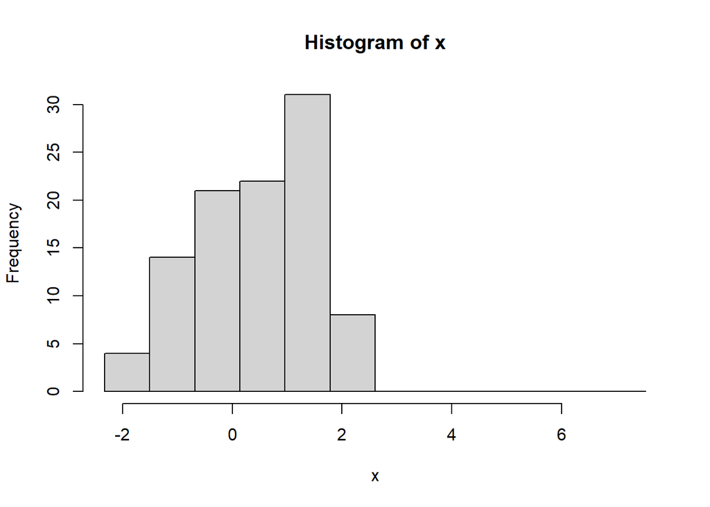

```r
hist(x,breaks=seq(A,Z+b,by=best_b), plot=T)
```

Scotts formula proposes the following bin width:

```r
3.49*sd(x)*100^(-1/3)
```

```
## [1] 0.8253815
```

The values are (in this case) pretty similar.

# Kernel Density Estimator

## Exercise 8

We consider the vector $x$ of data we have generated before from the mixture of two normals. We use the relationship (see exercise sheet) to select the value of $h$ maximizing the leave-one-out log-likelihood function.

```r
# we considered the following set as possible values for h
possible_hs <- seq(0.001,3,length=100)

likelihood_h <- c()

for (h in possible_hs){
  kx<- density(x, bw= h)
  kx_f<- approxfun(x=kx$x,y=kx$y, method='linear',rule=2)
  n=length(x)

  kx_f2 <- (n/(n-1))*(kx_f(x)-dnorm(0)/(n*h))
  kx_f2[kx_f2<0] <- 0
  looCV_log_lik=sum(log(kx_f2))
  likelihood_h <- append(likelihood_h,looCV_log_lik)
}

best_h <- possible_hs[which.max(likelihood_h)]

print(paste("bandwidth with highest leave one out log likelihood (of the ones we considered): ", best_h))
```

```
## [1] "bandwidth with highest leave one out log likelihood (of the ones we considered):  0.334222222222222"
```

Below we plot the corresponding kernel density estimator.

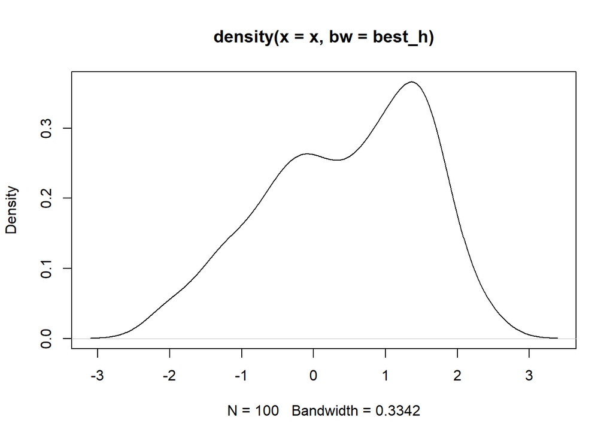

```r
plot(density(x, bw=best_h))
```